# logistic regression in R

Toshiaki Tameshige

2022-11-22

# Analyze demo data for logistic regression and likelihood-ratio test

libraries

```r
library(cmdstanr)
library(posterior)
library(bayesplot)
library(tidyverse)
```

define plotting function for stacked bar plot of observation ratio

```r
plot_ratiostackbar <- function(df, title="ratio-stack bar plot") {

  df <- na.omit(df)
  input_category <- unique(df[,1])
  output_number_positive <- integer(length(input_category))
  output_number_negative <- integer(length(input_category))

  for (i in 1:length(input_category)){
    df_single_category <- df[df[,1] == input_category[i],]
    output_number_positive[i] <- dim(df_single_category[df_single_category[,2] == 1,])[1]
    output_number_negative[i] <- dim(df_single_category[df_single_category[,2] == 0,])[1]
  }

  data_plotting <- data.frame(input_category = rep(input_category,2),
                              output_number = c(output_number_positive, output_number_negative),
                              output_class = rep(c("positive","negative"), each=length(input_category)))

  g <- ggplot(data_plotting, aes(fill=output_class, y=output_number, x=input_category)) +
    geom_bar(position="fill", stat="identity") +
    ylab("observation_ratio") +
    ggtitle(label=title)

  return(g)
 }
```

# demo data4 (probability range from 0% to 100%)

read demo_data4

```r
data <- read.delim("demoData_IR-LEGO_Cre-loxP_4.txt")
data
```

| laser_power | cell_size | recombination |
| --- | --- | --- |
| 5.0 | 5040.732 | 0 |
| 5.0 | 1288.368 | 0 |
| 5.0 | 4891.382 | 0 |
| 5.0 | 2441.501 | 0 |
| 5.0 | 2363.521 | 0 |
| 5.0 | 3723.757 | 0 |
| 5.0 | 3453.679 | 0 |
| 5.0 | 1927.796 | 0 |
| 5.0 | 4230.392 | 0 |
| 5.0 | 5386.121 | 0 |

[output cut: 682 more lines]

plot data overview

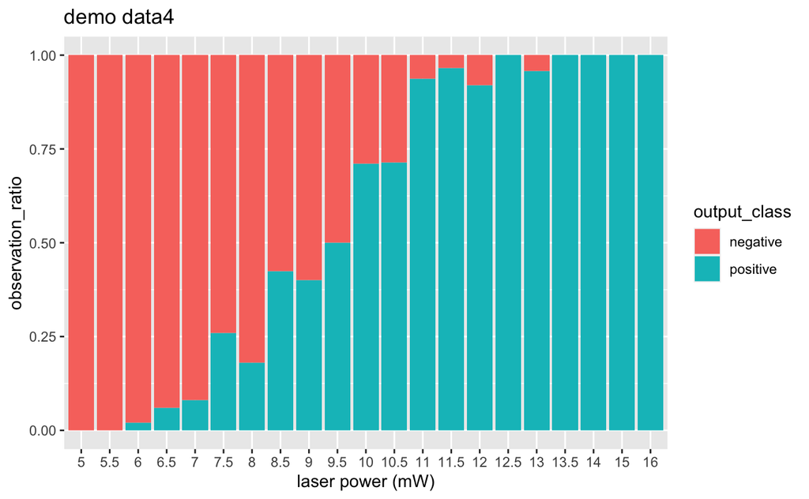

```r
data$laser_power <- as.factor(data$laser_power)
df <- data[,c("laser_power","recombination")]
g <- plot_ratiostackbar(df=df, title="demo data4")+xlab("laser power (mW)")
print(g)
```

plot the cell size distribution

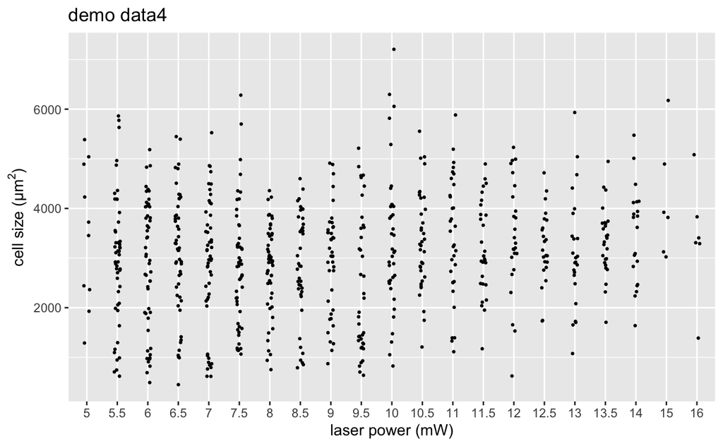

```r
data %>% ggplot(aes(x = laser_power, y = cell_size)) +
    geom_jitter(position = position_jitter(height = 0, width = 0.1), size=0.5) +
  xlab("laser power (mW)") +
  ylab(expression(paste ("cell size (", {µm^2}, ")", sep="")))+
  ggtitle("demo data4")
```

standard logistic modeling, that is glm() with link=“logit” here we assume cell-size effects on “intercept” (independent effect) and “slope” (interaction with laser_power)

```r
data <- read.delim("demoData_IR-LEGO_Cre-loxP_4.txt")    #import data
model <- glm(recombination ~ laser_power + cell_size + laser_power:cell_size, data=data,family=binomial(link="logit"))
summary(model)
```

```
Call:
glm(formula = recombination ~ laser_power + cell_size + laser_power:cell_size,
    family = binomial(link = "logit"), data = data)

Deviance Residuals:
     Min        1Q    Median        3Q       Max
-3.12859  -0.42458  -0.06385   0.33190   2.49293

Coefficients:
                        Estimate Std. Error z value Pr(>|z|)
(Intercept)           -4.715e+00  1.650e+00  -2.857 0.004274 **
laser_power            7.543e-01  1.953e-01   3.862 0.000113 ***
cell_size             -2.554e-03  6.289e-04  -4.061 4.88e-05 ***
laser_power:cell_size  1.912e-04  6.805e-05   2.810 0.004952 **
---
Signif. codes:  0 ‘***’ 0.001 ‘**’ 0.01 ‘*’ 0.05 ‘.’ 0.1 ‘ ’ 1

(Dispersion parameter for binomial family taken to be 1)

    Null deviance: 955.10  on 691  degrees of freedom
Residual deviance: 409.78  on 688  degrees of freedom
AIC: 417.78

Number of Fisher Scoring iterations: 6
```

plot the curves of the model at some cell sizes

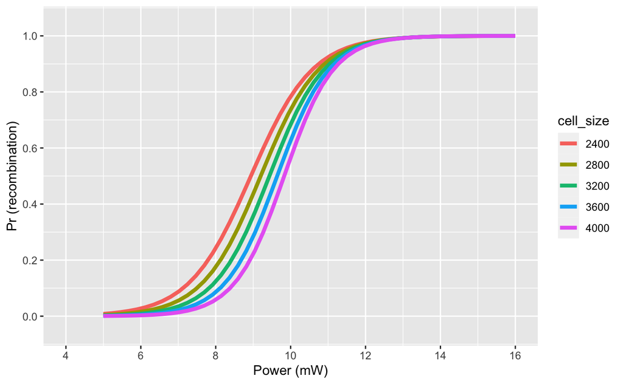

```r
cell_size_4plot <- c(2400,2800,3200,3600,4000)
n_xpoints <- 50

x <- seq(5, 16, length.out = n_xpoints)

plot_df <- data.frame(x=numeric(0),y=numeric(0),cell_size=numeric(0))

for (i in 1:length(cell_size_4plot)){
  y <- 1 / (1 + exp(- model$coefficients["(Intercept)"] - model$coefficients["laser_power"] * x - model$coefficients["cell_size"] * cell_size_4plot[i] - model$coefficients["laser_power:cell_size"] *x* cell_size_4plot[i]))    # simulate y according to the model
  each_df <- data.frame(x, y,cell_size=rep(cell_size_4plot[i],times=n_xpoints))
  plot_df <- rbind(plot_df,each_df)
}
plot_df$cell_size <- as.factor(plot_df$cell_size)

#plot with variation in cell size
p <- ggplot(data = plot_df) +
  geom_line(aes(x=x, y=y, color=cell_size), size = 1.5) +
  scale_x_continuous("Power (mW)", limits = c(4, 16), breaks = seq(4, 16, 2),
                       ) +
    scale_y_continuous("Pr (recombination)", limits = c(-0.05, 1.05),
                       breaks = seq(0, 1, 0.2))
print(p)
```

likelihood-ratio test

```r
library(lmtest)

#model1 is a reduced model
model1 <- glm(recombination ~ laser_power, data=data,family=binomial(link="logit"))
# model2 is a full model
model2 <- glm(recombination ~ laser_power + cell_size + laser_power:cell_size, data=data,family=binomial(link="logit"))

#likelihood-ratio test
lrtest(model2,model1)
```

```
Likelihood ratio test

Model 1: recombination ~ laser_power + cell_size + laser_power:cell_size
Model 2: recombination ~ laser_power
  #Df  LogLik Df  Chisq Pr(>Chisq)
1   4 -204.89
2   2 -238.78 -2 67.785  1.909e-15 ***
---
Signif. codes:  0 ‘***’ 0.001 ‘**’ 0.01 ‘*’ 0.05 ‘.’ 0.1 ‘ ’ 1
```

The cell_size effect is significant!

# demo data3 (not achieving 100% probability)

read demo_data3

```r
data <- read.delim("demoData_IR-LEGO_Cre-loxP_3.txt")
data
```

| laser_power | cell_size | recombination |
| --- | --- | --- |
| 5.0 | 5040.732 | 0 |
| 5.0 | 1288.368 | 0 |
| 5.0 | 4891.382 | 0 |
| 5.0 | 2441.501 | 0 |
| 5.0 | 2363.521 | 0 |
| 5.0 | 3723.757 | 0 |
| 5.0 | 3453.679 | 0 |
| 5.0 | 1927.796 | 0 |
| 5.0 | 4230.392 | 0 |
| 5.0 | 5386.121 | 0 |

[output cut: 685 more lines]

plot data overview

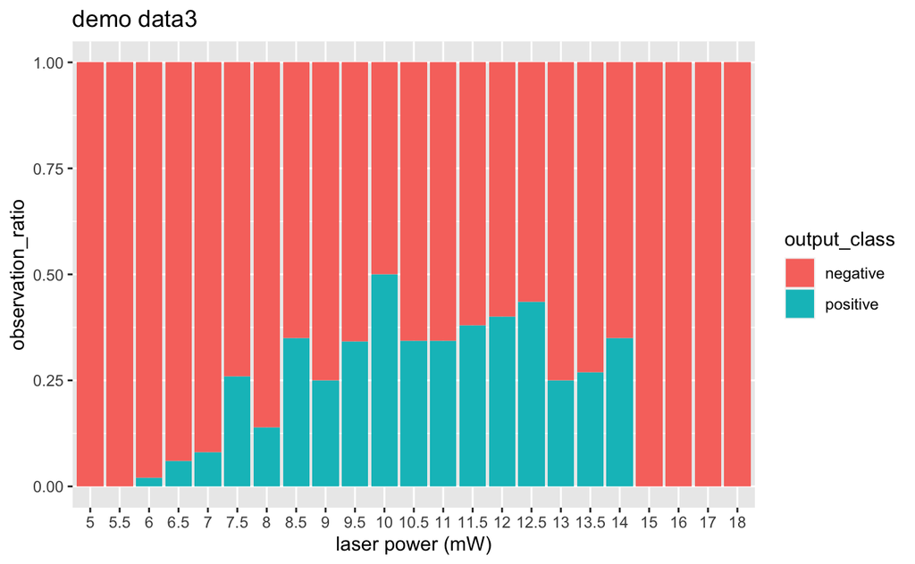

```r
data$laser_power <- as.factor(data$laser_power)
df <- data[,c("laser_power","recombination")]
g <- plot_ratiostackbar(df=df, title="demo data3")+xlab("laser power (mW)")
print(g)
```

select laser power range for a increasing function of logistic model

```r
power_upper_limit <- 15    #set upper limit of fitting data

data <- read.delim("demoData_IR-LEGO_Cre-loxP_3.txt")    #import data
data <- data[data$laser_power < power_upper_limit,] # power filtering suitable for logistic regression that is sigmoid curve

#scaling of the cell size data
data$cell_size.scale <- as.numeric(scale(data$cell_size))

dim(data)
```

```
[1] 680   4
```

format the data to be input into the sampler

```r
data.list <- list(N=dim(data)[1],
                        induction=data$recombination,
                        power=data$laser_power,
                        size=data$cell_size.scale)
print(data.list)
```

```
$N
[1] 680

$induction
  [1] 0 0 0 0 0 0 0 0 0 0 0 0 0 0 0 0 0 0 0 0 0 0 0 0 0 0 0 0 0 0 0 0 0 0 0 0 0 0 0 0 0 0
 [43] 0 0 0 0 0 0 0 0 0 0 0 0 0 0 0 0 0 0 1 0 0 0 0 0 0 0 0 0 0 0 0 0 0 0 0 0 0 0 0 0 0 0
 [85] 0 0 0 0 0 0 0 0 0 0 0 0 0 0 0 0 0 0 0 0 0 0 0 0 0 0 0 1 0 0 1 0 0 0 0 0 0 0 0 1 0 0
[127] 0 0 0 0 0 0 0 0 0 0 0 0 0 0 0 0 0 0 0 0 0 0 0 0 0 0 0 0 0 0 0 0 0 0 1 0 1 1 0 0 0 0
[169] 0 0 0 0 0 0 0 0 0 0 0 0 0 0 0 0 0 0 0 0 0 0 0 0 0 0 0 0 0 0 0 0 0 1 0 0 0 0 0 0 0 0
[211] 0 0 0 0 1 1 1 1 0 1 0 1 1 1 0 0 0 1 0 0 0 0 0 0 0 1 0 0 0 0 0 1 0 0 0 0 0 0 0 0 0 0
[253] 0 1 0 1 0 0 0 0 1 0 0 0 0 0 0 0 0 0 0 0 0 0 0 1 0 1 0 0 0 0 0 1 0 0 0 0 0 0 1 0 0 0
[295] 0 0 1 0 0 0 0 0 0 1 0 0 0 0 0 0 1 1 0 0 1 0 0 0 0 1 0 0 0 0 0 1 0 1 0 1 0 1 0 0 1 0
[337] 1 0 0 0 1 0 0 0 1 1 1 0 0 0 1 0 0 0 0 1 1 1 0 1 0 0 1 0 0 0 0 1 0 0 0 0 1 0 0 0 0 1
[379] 0 0 1 0 0 0 0 0 0 0 0 0 1 1 1 0 0 0 1 0 1 0 1 0 0 0 0 0 1 0 1 0 1 0 1 0 1 0 0 0 0 1
[421] 0 0 0 0 0 0 1 0 0 1 1 0 1 0 0 0 0 0 1 1 0 1 1 1 0 0 1 0 1 1 1 1 1 0 1 1 0 1 1 0 0 0
```

[output cut: 164 more lines]

compile stan model

```r
file <- "IR-LEGO_creloxp_logit_plimitcellsize_model.stan" #define the model file
mod <- cmdstan_model(file)    #compile the model
```

[output not shown]

[output cut: 14 more lines]

[output not shown]

[output not shown]

check stan model

```r
mod$print()    #display the model code
```

```
data {
  int<lower=0> N;
  vector[N] power;
  vector[N] size;
  int<lower=0,upper=1> induction[N];
}
parameters {
  real<lower=-1,upper=5> alpha_one;
  real<lower=-10,upper=2> alpha_two;
  real<lower=-5,upper=5> alpha_three;
  real<lower=-40,upper=10> beta;
  real<lower=-1,upper=1> plimit_b;
  real<lower=-1,upper=1> plimit_a;
}
transformed parameters {
  real<lower=-100,upper=100> x[N];
  for (k in 1:N)
    x[k]=(plimit_b+plimit_a*size[k])*Phi_approx(beta+alpha_one*power[k]+alpha_two*size[k]+alpha_three*power[k]*size[k]);
}
model {
  for (n in 1:N)
    induction[n] ~ bernoulli(x[n]);
}
```

MCMC Sampling

```r
### MCMC sampling for logistic model: induction ~ power+size+power:size
fit_plimitsize_model <- mod$sample(
  data = data.list,
  seed = 111,
  adapt_delta = 0.999,
  chains = 4,
  parallel_chains = 2,
  refresh = 500
)
```

```
Running MCMC with 4 chains, at most 2 in parallel...
```

[output not shown]

[output cut: 82 more lines]

[output not shown]

```
Chain 2 Iteration:    1 / 2000 [  0%]  (Warmup)
```

[output not shown]

[output cut: 64 more lines]

[output not shown]

```
Chain 1 Iteration:    1 / 2000 [  0%]  (Warmup)
```

[output not shown]

```
Chain 2 Iteration:  500 / 2000 [ 25%]  (Warmup)
Chain 1 Iteration:  500 / 2000 [ 25%]  (Warmup)
```

[output not shown]

```
Chain 2 Iteration: 1000 / 2000 [ 50%]  (Warmup)
Chain 2 Iteration: 1001 / 2000 [ 50%]  (Sampling)
Chain 1 Iteration: 1000 / 2000 [ 50%]  (Warmup)
Chain 1 Iteration: 1001 / 2000 [ 50%]  (Sampling)
```

[output not shown]

```
Chain 1 Iteration: 1500 / 2000 [ 75%]  (Sampling)
Chain 2 Iteration: 1500 / 2000 [ 75%]  (Sampling)
Chain 1 Iteration: 2000 / 2000 [100%]  (Sampling)
Chain 1 finished in 44.7 seconds.
```

[output not shown]

[output cut: 12 more lines]

[output not shown]

```
Chain 3 Iteration:    1 / 2000 [  0%]  (Warmup)
```

[output not shown]

[output cut: 20 more lines]

```
Chain 2 Iteration: 2000 / 2000 [100%]  (Sampling)
Chain 2 finished in 51.5 seconds.
```

[output not shown]

[output cut: 8 more lines]

[output not shown]

```
Chain 4 Iteration:    1 / 2000 [  0%]  (Warmup)
```

[output not shown]

```
Chain 3 Iteration:  500 / 2000 [ 25%]  (Warmup)
```

[output not shown]

```
Chain 3 Iteration: 1000 / 2000 [ 50%]  (Warmup)
Chain 3 Iteration: 1001 / 2000 [ 50%]  (Sampling)
Chain 4 Iteration:  500 / 2000 [ 25%]  (Warmup)
Chain 3 Iteration: 1500 / 2000 [ 75%]  (Sampling)
Chain 4 Iteration: 1000 / 2000 [ 50%]  (Warmup)
Chain 4 Iteration: 1001 / 2000 [ 50%]  (Sampling)
Chain 3 Iteration: 2000 / 2000 [100%]  (Sampling)
Chain 3 finished in 33.7 seconds.
Chain 4 Iteration: 1500 / 2000 [ 75%]  (Sampling)
```

[output not shown]

```
Chain 4 Iteration: 2000 / 2000 [100%]  (Sampling)
Chain 4 finished in 43.2 seconds.

All 4 chains finished successfully.
Mean chain execution time: 43.3 seconds.
Total execution time: 95.0 seconds.
```

check diagnostics

```r
fit_plimitsize_model$cmdstan_diagnose()
```

[output not shown]

check sampling summary

```r
fit_plimitsize_model$cmdstan_summary()
```

[output not shown]

trace plot

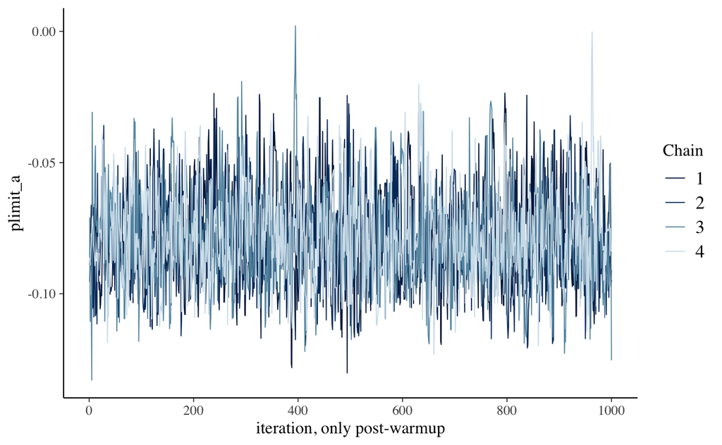

```r
#trace plot plimit_a
mcmc_trace(fit_plimitsize_model$draws("plimit_a")) +
  xlab("iteration, only post-warmup")
```

sampled posterior distribution

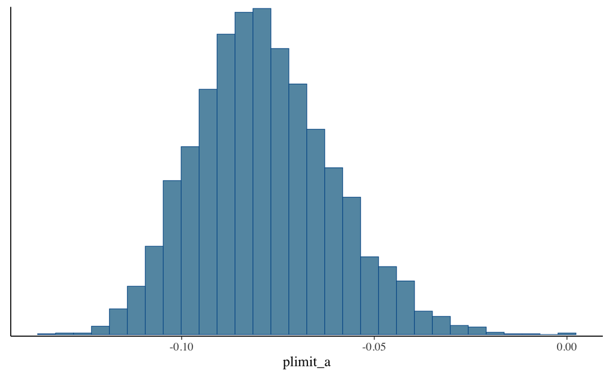

```r
mcmc_hist(fit_plimitsize_model$draws("plimit_a"))
```

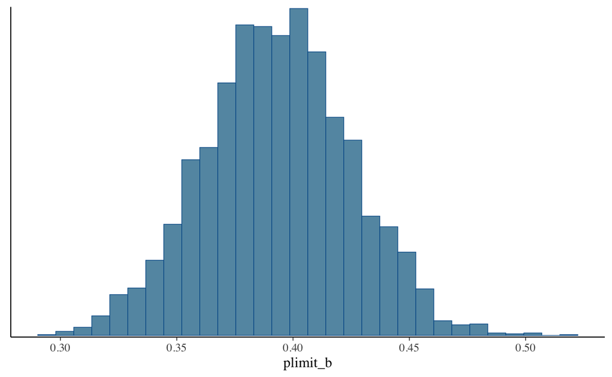

```r
mcmc_hist(fit_plimitsize_model$draws("plimit_b"))
```

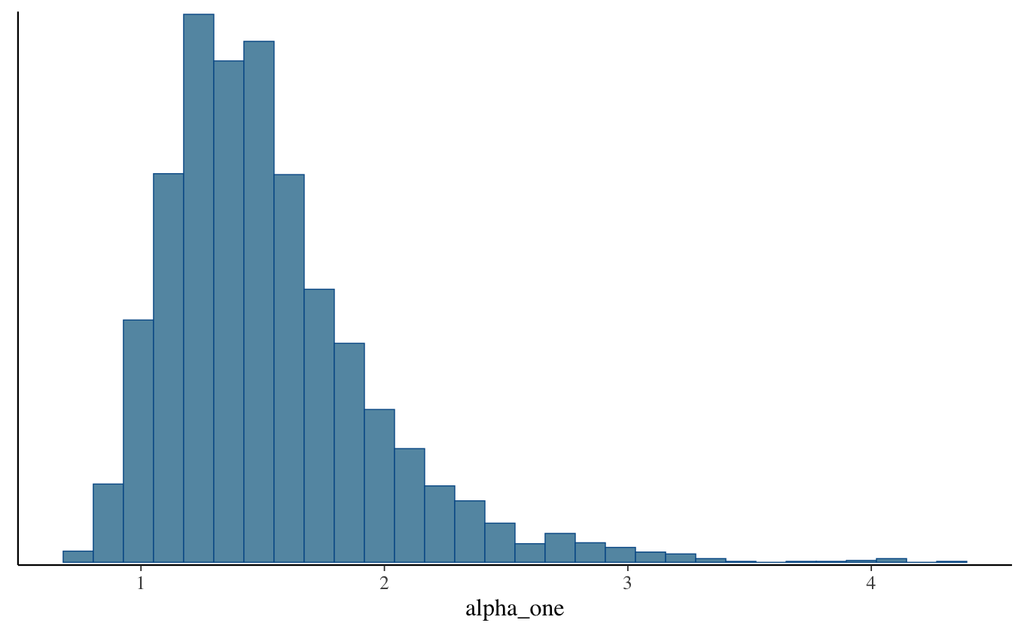

```r
mcmc_hist(fit_plimitsize_model$draws("alpha_one"))
```

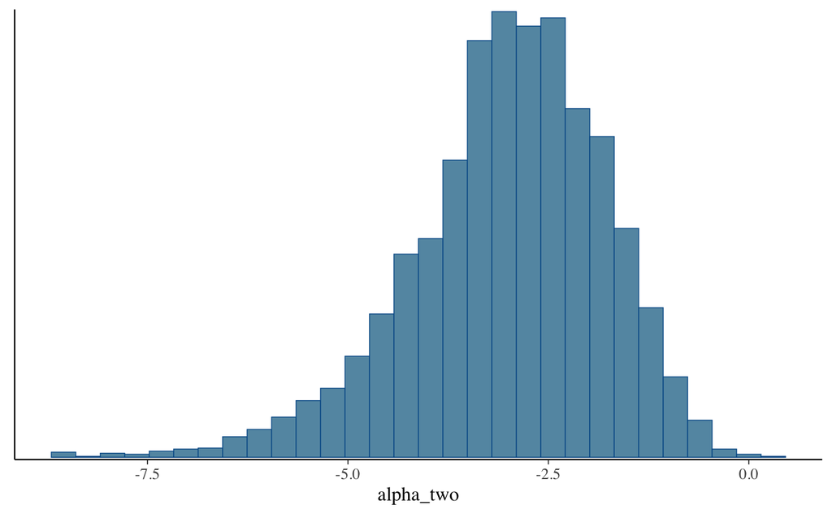

```r
mcmc_hist(fit_plimitsize_model$draws("alpha_two"))
```

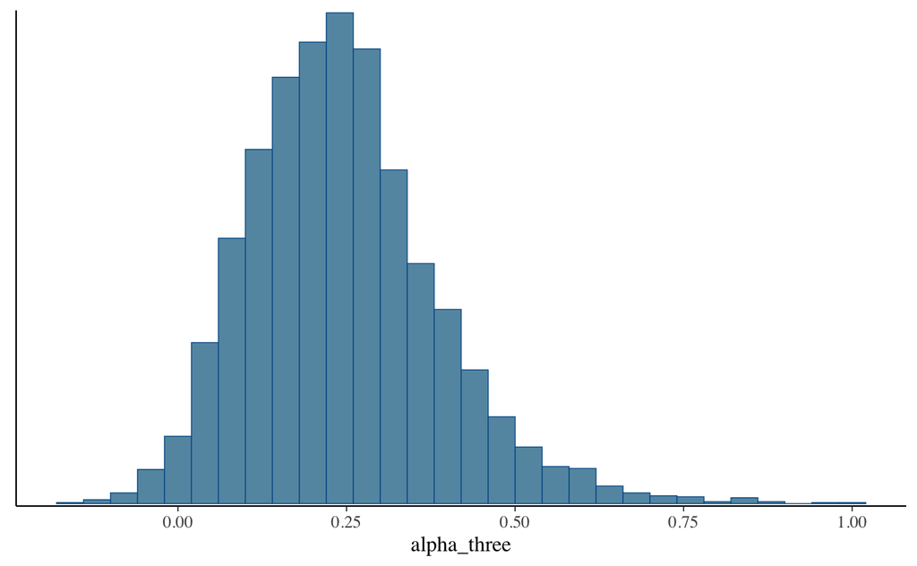

```r
mcmc_hist(fit_plimitsize_model$draws("alpha_three"))
```

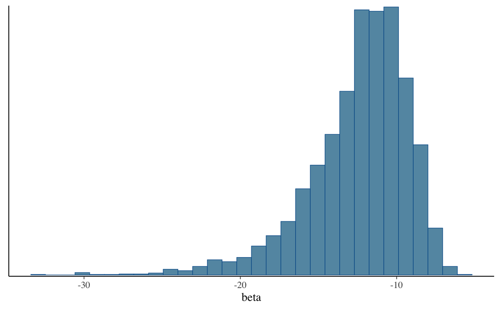

```r
mcmc_hist(fit_plimitsize_model$draws("beta"))
```

Now, we adopt the median values of parameter samples because some distribution shows skewness making the mean values not the best representative. get median values from the samples as the maximum likelihood parameters

```r
alpha_one <- median(fit_plimitsize_model$draws("alpha_one"))
alpha_two <- median(fit_plimitsize_model$draws("alpha_two"))
alpha_three <- median(fit_plimitsize_model$draws("alpha_three"))
beta <- median(fit_plimitsize_model$draws("beta"))
p.limit_b <- median(fit_plimitsize_model$draws("plimit_b"))
p.limit_a <- median(fit_plimitsize_model$draws("plimit_a"))
```

plot the model at some cell sizes: 2400,2800,3200,3600,4000

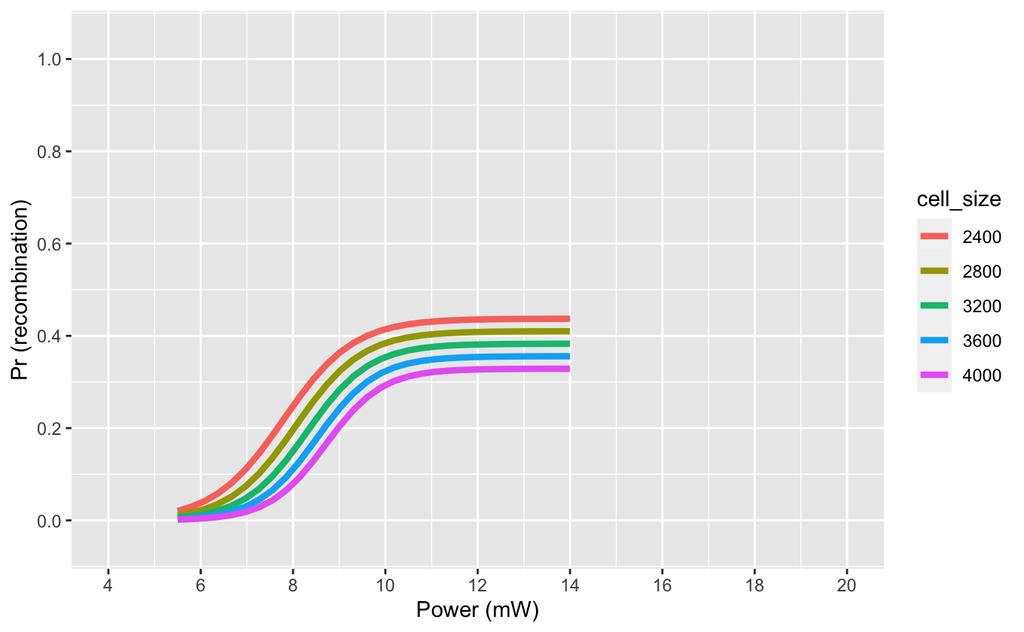

```r
cell_size_4plot <- c(2400,2800,3200,3600,4000)

mean_cell_size_raw <- mean(data$cell_size)
sd_cell_size_raw <- sd(data$cell_size)
cell_size_4plot.scale <- (cell_size_4plot - mean_cell_size_raw)/sd_cell_size_raw    #scale the cell size

n_xpoints <- 30
plot_df <- data.frame(x=numeric(0),y=numeric(0),cell_size=numeric(0))

for (i in 1:length(cell_size_4plot)){
  x <- seq(5.5, 14, length.out = n_xpoints)
  y <- (p.limit_b + cell_size_4plot.scale[i]*p.limit_a) / (1 + exp(- beta - alpha_one * x - alpha_two * cell_size_4plot.scale[i] - alpha_three*x*cell_size_4plot.scale[i]))
  each_df <- data.frame(x, y,cell_size=rep(cell_size_4plot[i],times=n_xpoints))
  plot_df <- rbind(plot_df,each_df)
}
plot_df$cell_size <- as.factor(plot_df$cell_size)

p <- ggplot(data = plot_df) +
  geom_line(aes(x=x, y=y, color=cell_size), size = 1.5) +
  scale_x_continuous("Power (mW)", limits = c(4, 20), breaks = seq(4, 20, 2),
                       ) +
    scale_y_continuous("Pr (recombination)", limits = c(-0.05, 1.05),
                       breaks = seq(0, 1, 0.2))
print(p)
```

next, calcurate deviance of the models full model with cell_size, cell_size-laser_power interaction and cell_size-p.limit interaction

```r
new_x1 <- data$laser_power
new_x2 <- data$cell_size.scale

pred_prob <- (p.limit_b + new_x2*p.limit_a) / (1 + exp(- beta - alpha_one * new_x1 - alpha_two * new_x2 - alpha_three*new_x1*new_x2))   #get the induction rate, or probability, predicted from our bayesian model with laser power and cell size

#calculate deviance by simply multiplying of probabilities
pos <- (data$recombination == 1)
neg <- (data$recombination == 0)

#probability of unsuccess
pred_prob_false <- 1- pred_prob

manual_loglikelihood <- sum(log(pred_prob[pos])) + sum(log(pred_prob_false[neg]))

manual_deviance_model1 <- -2*manual_loglikelihood
paste0("full model deviance = ",manual_deviance_model1)
```

```
[1] "full model deviance = 589.397668145755"
```

next, a reduced model ignoring cell-size effect format the data to be input into the sampler

```r
data.list <- list(N=dim(data)[1],
                        induction=data$recombination,
                        power=data$laser_power)
print(data.list)
```

```
$N
[1] 680

$induction
  [1] 0 0 0 0 0 0 0 0 0 0 0 0 0 0 0 0 0 0 0 0 0 0 0 0 0 0 0 0 0 0 0 0 0 0 0 0 0 0 0 0 0 0
 [43] 0 0 0 0 0 0 0 0 0 0 0 0 0 0 0 0 0 0 1 0 0 0 0 0 0 0 0 0 0 0 0 0 0 0 0 0 0 0 0 0 0 0
 [85] 0 0 0 0 0 0 0 0 0 0 0 0 0 0 0 0 0 0 0 0 0 0 0 0 0 0 0 1 0 0 1 0 0 0 0 0 0 0 0 1 0 0
[127] 0 0 0 0 0 0 0 0 0 0 0 0 0 0 0 0 0 0 0 0 0 0 0 0 0 0 0 0 0 0 0 0 0 0 1 0 1 1 0 0 0 0
[169] 0 0 0 0 0 0 0 0 0 0 0 0 0 0 0 0 0 0 0 0 0 0 0 0 0 0 0 0 0 0 0 0 0 1 0 0 0 0 0 0 0 0
[211] 0 0 0 0 1 1 1 1 0 1 0 1 1 1 0 0 0 1 0 0 0 0 0 0 0 1 0 0 0 0 0 1 0 0 0 0 0 0 0 0 0 0
[253] 0 1 0 1 0 0 0 0 1 0 0 0 0 0 0 0 0 0 0 0 0 0 0 1 0 1 0 0 0 0 0 1 0 0 0 0 0 0 1 0 0 0
[295] 0 0 1 0 0 0 0 0 0 1 0 0 0 0 0 0 1 1 0 0 1 0 0 0 0 1 0 0 0 0 0 1 0 1 0 1 0 1 0 0 1 0
[337] 1 0 0 0 1 0 0 0 1 1 1 0 0 0 1 0 0 0 0 1 1 1 0 1 0 0 1 0 0 0 0 1 0 0 0 0 1 0 0 0 0 1
[379] 0 0 1 0 0 0 0 0 0 0 0 0 1 1 1 0 0 0 1 0 1 0 1 0 0 0 0 0 1 0 1 0 1 0 1 0 1 0 0 0 0 1
[421] 0 0 0 0 0 0 1 0 0 1 1 0 1 0 0 0 0 0 1 1 0 1 1 1 0 0 1 0 1 1 1 1 1 0 1 1 0 1 1 0 0 0
```

[output cut: 48 more lines]

compile stan model

```r
file <- "IR-LEGO_creloxp_logit_plimit_model.stan" #define the model file
mod <- cmdstan_model(file)    #compile the model
```

```
Model executable is up to date!
```

check stan model

```r
mod$print()    #display the model code
```

[output not shown]

```r
### MCMC sampling for logistic model: induction ~ power
fit_plimit_model <- mod$sample(
  data = data.list,
  seed = 111,
  adapt_delta = 0.999,
  chains = 4,
  parallel_chains = 2,
  refresh = 500
)
```

[output not shown]

check the posterior

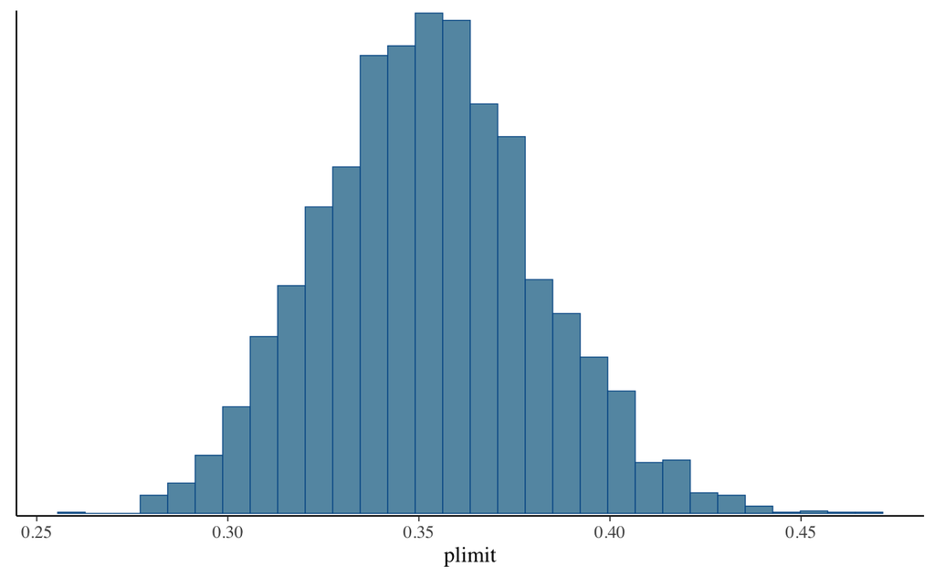

```r
mcmc_hist(fit_plimit_model$draws("plimit"))
```

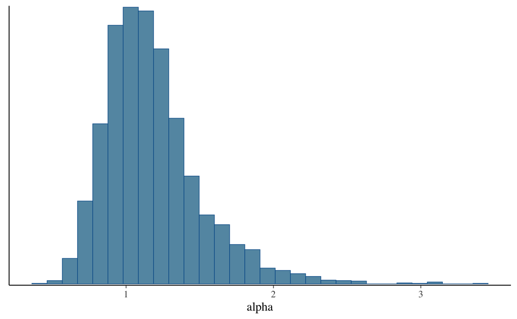

```r
mcmc_hist(fit_plimit_model$draws("alpha"))
```

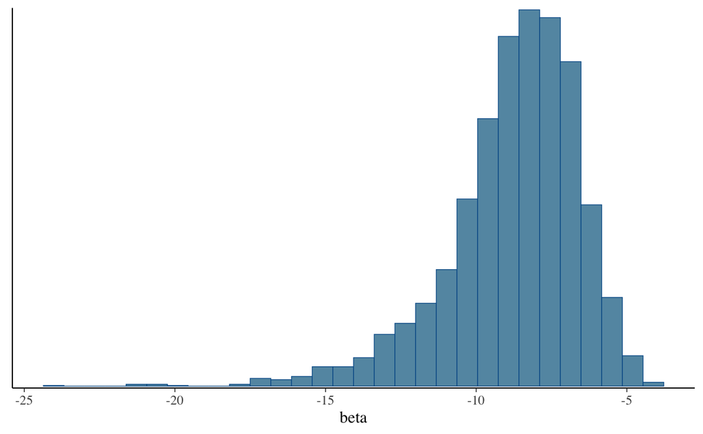

```r
mcmc_hist(fit_plimit_model$draws("beta"))
```

get median values from the samples as the maximum likelihood parameters

```r
alpha <- median(fit_plimit_model$draws("alpha"))
beta <- median(fit_plimit_model$draws("beta"))
p.limit <- median(fit_plimit_model$draws("plimit"))
```

plot the resulting model

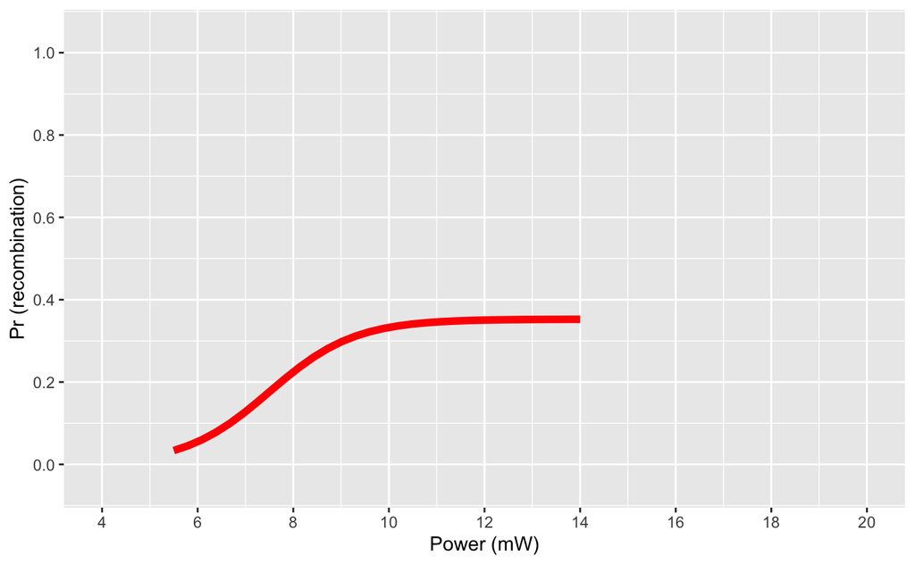

```r
x <- seq(5.5, 14, length.out = 30)
y <- p.limit / (1 + exp(- beta - alpha * x))
plot_df <- data.frame(x, y)

p <- ggplot() +
  geom_line(aes(x, y), data = plot_df, size = 2, color="red") +

  scale_x_continuous("Power (mW)", limits = c(4, 20), breaks = seq(4, 20, 2),
                       ) +
    scale_y_continuous("Pr (recombination)", limits = c(-0.05, 1.05),
                       breaks = seq(0, 1, 0.2))
print(p)
```

```r
new_x <- data$laser_power

pred_prob <- p.limit / (1 + exp(- beta - alpha * new_x ))   # induction rate, or probability, predicted from our model with only laser power

pos <- (data$recombination == 1)
neg <- (data$recombination == 0)

#probability of unsuccess
pred_prob_false <- 1- pred_prob

manual_loglikelihood <- sum(log(pred_prob[pos])) + sum(log(pred_prob_false[neg]))

manual_deviance_model2 <- -2*manual_loglikelihood
paste0("cell size-ignored model deviance = ",manual_deviance_model2)
```

```
[1] "cell size-ignored model deviance = 650.402551435352"
```

Then difference of deviance is

```r
diff_dev <- manual_deviance_model2 - manual_deviance_model1
print(diff_dev)
```

```
[1] 61.00488
```

What is chisq value at df=3, p<0.05?

```r
qchisq(0.05,3,lower.tail = FALSE)
```

```
[1] 7.814728
```

the p-value of the likelihood-raio test of our bayesian models

```r
p_LRT <- pchisq(diff_dev, 3,lower.tail = FALSE)
paste0("likelihood-ratio test, p = ",p_LRT)
```

```
[1] "likelihood-ratio test, p = 3.58535337832115e-13"
```

The cell_size effect is significant!